# androgenReceptor_DE

Melanie Smith

17/8/2022

## Load R Packages

```r
# Working with data:
library(dplyr)
library(magrittr)
library(readr)
library(tibble)
library(reshape2)
# Visualisation:
library(kableExtra)
library(ggplot2)
library(ggbiplot)
library(ggrepel)
library(grid)
library(RColorBrewer)
# Set ggplot theme
theme_set(theme_bw())
# Other packages:
library(here)
# Bioconductor packages:
library(AnnotationHub)
library(edgeR)
library(limma)
library(Glimma)
```

## Import Data

- The first step is to import the gene counts and sample metadata data into R.

```r
grch38_mRNA_placenta_counts <- readr::read_csv(here("rawData",
                               "new_counts_unchanged.csv"),
                          col_names = TRUE) %>%
  as.data.frame %>%
  tibble::column_to_rownames("...1")
```

## Gene Annotations

### Import Gene Annotation Data

- Gene annotations are useful for later interpreting the results of the differential gene expression analysis. They give information about genes, including genomic location (e.g. start and end coordinates), descriptions, type of gene (e.g. whether it's a non-coding or protein-coding gene) etc.
- Below, we retrieve gene annotation metadata from the Ensembl database using build GRCh38 (this step can take a while to run if running `AnnotationHub` for the first time, so I have saved out the `genes` object as an R object).

```r
# uncomment if running without a saved annotation file

# # Load annotation hub
# ah <- AnnotationHub()
#
# # Search for the correct Ensembl gene annotation
# ah %>%
#   subset(grepl("sapiens", species)) %>%
#   subset(rdataclass == "EnsDb")
#
# ensDb <- ah[["AH78783"]]
#
# # Get gene annotations
# genes <- genes(ensDb) %>%
#   as.data.frame
#
# # save the annotation file
# genes %>% saveRDS(here("cleanData/genes.rds"))
```

### Load Gene Annotation Data from file

```r
# if AnnotationHub objects are pre-downloaded.
genes <- readRDS(here("cleanData/genes.rds"))
```

- The `genes` data.frame is prepared so that the `row.names` (corresponding to Ensembl gene IDs) are in the same order as for the gene count matrix stored in `grch38_mRNA_placenta_counts`.

```r
genes <- data.frame(gene = rownames(grch38_mRNA_placenta_counts)) %>%
  left_join(genes %>% as.data.frame,
            by = c("gene"="gene_name")) %>%
  dplyr::distinct(gene, .keep_all=TRUE)

rownames(genes) <- genes$gene
```

```r
genes$gene_biotype %>%
  table %>%
  data.frame() %>%
  set_colnames(c("gene_biotype", "frequency")) %>%
  dplyr::arrange(., desc(frequency)) %>%
  kableExtra::kable() %>%
  kableExtra::kable_styling(full_width = F) %>%
  kableExtra::scroll_box(height = "600px")
```

| gene_biotype | frequency |
| --- | --- |
| protein_coding | 19095 |
| lncRNA | 4002 |
| processed_pseudogene | 3755 |
| miRNA | 1854 |
| unprocessed_pseudogene | 566 |
| transcribed_unprocessed_pseudogene | 515 |
| snoRNA | 433 |
| snRNA | 290 |
| transcribed_processed_pseudogene | 234 |
| misc_RNA | 184 |
| IG_V_pseudogene | 148 |
| LRG_gene | 145 |
| IG_V_gene | 130 |
| TR_V_gene | 106 |
| transcribed_unitary_pseudogene | 85 |
| TR_J_gene | 79 |
| polymorphic_pseudogene | 43 |
| TR_V_pseudogene | 33 |
| IG_D_gene | 27 |
| rRNA | 23 |
| scaRNA | 19 |
| IG_J_gene | 18 |
| rRNA_pseudogene | 17 |
| IG_C_gene | 14 |
| TEC | 11 |
| unitary_pseudogene | 10 |
| TR_C_gene | 6 |
| IG_C_pseudogene | 5 |
| TR_D_gene | 4 |
| TR_J_pseudogene | 4 |
| IG_J_pseudogene | 3 |
| ribozyme | 1 |
| scRNA | 1 |
| translated_unprocessed_pseudogene | 1 |
| vaultRNA | 1 |

```r
# preview the genes information
genes %>%
  head(50) %>%
  kable %>%
  kable_styling %>%
  scroll_box(height = "600px")
```

start

end

width

strand

gene_id

gene_biotype

seq_coord_system

description

gene_id_version

symbol

entrezid

DDX11L1

1

11869

14409

2541

ENSG00000223972

transcribed_unprocessed_pseudogene

chromosome

DEAD/H-box helicase 11 like 1 [Source:HGNC Symbol;Acc:HGNC:37102]

ENSG00000223972.5

DDX11L1

NA

WASH7P

WASH7P

1

14404

29570

15167

ENSG00000227232

unprocessed_pseudogene

chromosome

WASP family homolog 7, pseudogene [Source:HGNC Symbol;Acc:HGNC:38034]

ENSG00000227232.5

WASH7P

NA

MIR6859-1

MIR6859-1

1

17369

17436

68

ENSG00000278267

miRNA

chromosome

microRNA 6859-1 [Source:HGNC Symbol;Acc:HGNC:50039]

ENSG00000278267.1

MIR6859-1

NA

MIR1302-2HG

MIR1302-2HG

1

29554

31109

1556

ENSG00000243485

lncRNA

chromosome

MIR1302-2 host gene [Source:HGNC Symbol;Acc:HGNC:52482]

ENSG00000243485.5

MIR1302-2HG

NA

MIR1302-2

MIR1302-2

1

30366

30503

138

ENSG00000284332

miRNA

chromosome

microRNA 1302-2 [Source:HGNC Symbol;Acc:HGNC:35294]

ENSG00000284332.1

MIR1302-2

NA

FAM138A

FAM138A

1

34554

36081

1528

ENSG00000237613

lncRNA

chromosome

family with sequence similarity 138 member A [Source:HGNC Symbol;Acc:HGNC:32334]

ENSG00000237613.2

FAM138A

NA

OR4F5

OR4F5

1

65419

71585

6167

ENSG00000186092

protein_coding

chromosome

olfactory receptor family 4 subfamily F member 5 [Source:HGNC Symbol;Acc:HGNC:14825]

ENSG00000186092.6

OR4F5

79501

LOC100996442

NA

NA

NA

NA

NA

NA

NA

NA

NA

NA

NA

SEPTIN14P18

SEPTIN14P18

NA

NA

NA

NA

NA

NA

NA

NA

NA

NA

NA

CICP27

CICP27

1

131025

134836

3812

ENSG00000233750

processed_pseudogene

chromosome

capicua transcriptional repressor pseudogene 27 [Source:HGNC Symbol;Acc:HGNC:48835]

ENSG00000233750.3

CICP27

NA

LOC729737

LOC729737

NA

NA

NA

NA

NA

NA

NA

NA

NA

NA

NA

LOC102725121

LOC102725121

NA

NA

NA

NA

NA

NA

NA

NA

NA

NA

NA

WASH9P

WASH9P

1

185217

195411

10195

ENSG00000279457

unprocessed_pseudogene

chromosome

WAS protein family homolog 9, pseudogene [Source:HGNC Symbol;Acc:HGNC:53981]

ENSG00000279457.4

WASH9P

NA

MIR6859-2

MIR6859-2

1

187891

187958

68

ENSG00000273874

miRNA

chromosome

microRNA 6859-2 [Source:HGNC Symbol;Acc:HGNC:49954]

ENSG00000273874.1

MIR6859-2

NA

LOC107985721

LOC107985721

NA

NA

NA

NA

NA

NA

NA

NA

NA

NA

NA

RPL23AP21

RPL23AP21

NA

NA

NA

NA

NA

NA

NA

NA

NA

NA

NA

RPL23AP24

RPL23AP24

1

347982

348366

385

ENSG00000236679

processed_pseudogene

chromosome

ribosomal protein L23a pseudogene 24 [Source:HGNC Symbol;Acc:HGNC:36176]

ENSG00000236679.2

RPL23AP24

NA

LOC112268260

LOC112268260

NA

NA

NA

NA

NA

NA

NA

NA

NA

NA

NA

WBP1LP7

WBP1LP7

1

439870

440232

363

ENSG00000269732

processed_pseudogene

chromosome

WBP1L pseudogene 7 [Source:HGNC Symbol;Acc:HGNC:43955]

ENSG00000269732.1

WBP1LP7

NA

OR4F29

OR4F29

1

450703

451697

995

ENSG00000284733

protein_coding

chromosome

olfactory receptor family 4 subfamily F member 29 [Source:HGNC Symbol;Acc:HGNC:31275]

ENSG00000284733.1

OR4F29

729759

SEPTIN14P13

SEPTIN14P13

NA

NA

NA

NA

NA

NA

NA

NA

NA

NA

NA

CICP7

CICP7

1

487101

489906

2806

ENSG00000233653

processed_pseudogene

chromosome

capicua transcriptional repressor pseudogene 7 [Source:HGNC Symbol;Acc:HGNC:37756]

ENSG00000233653.3

CICP7

NA

LOC100132287

LOC100132287

NA

NA

NA

NA

NA

NA

NA

NA

NA

NA

NA

LOC105378947

LOC105378947

NA

NA

NA

NA

NA

NA

NA

NA

NA

NA

NA

LOC101928626

LOC101928626

NA

NA

NA

NA

NA

NA

NA

NA

NA

NA

NA

MIR12136

MIR12136

NA

NA

NA

NA

NA

NA

NA

NA

NA

NA

NA

WBP1LP6

WBP1LP6

1

674842

675265

424

ENSG00000268663

processed_pseudogene

chromosome

WBP1L pseudogene 6 [Source:HGNC Symbol;Acc:HGNC:43956]

ENSG00000268663.1

WBP1LP6

NA

OR4F16

OR4F16

1

685679

686673

995

ENSG00000284662

protein_coding

chromosome

olfactory receptor family 4 subfamily F member 16 [Source:HGNC Symbol;Acc:HGNC:15079]

ENSG00000284662.1

OR4F16

81399

SEPTIN14P14

SEPTIN14P14

NA

NA

NA

NA

NA

NA

NA

NA

NA

NA

NA

CICP3

CICP3

1

722092

724903

2812

ENSG00000229376

processed_pseudogene

chromosome

capicua transcriptional repressor pseudogene 3 [Source:HGNC Symbol;Acc:HGNC:37742]

ENSG00000229376.3

CICP3

NA

LOC100133331

LOC100133331

NA

NA

NA

NA

NA

NA

NA

NA

NA

NA

NA

LOC107984841

LOC107984841

NA

NA

NA

NA

NA

NA

NA

NA

NA

NA

NA

LOC107984847

LOC107984847

NA

NA

NA

NA

NA

NA

NA

NA

NA

NA

NA

LOC107984849

LOC107984849

NA

NA

NA

NA

NA

NA

NA

NA

NA

NA

NA

LOC100288069

LOC100288069

NA

NA

NA

NA

NA

NA

NA

NA

NA

NA

NA

LINC01409

LINC01409

1

778747

810065

31319

ENSG00000237491

lncRNA

chromosome

long intergenic non-protein coding RNA 1409 [Source:HGNC Symbol;Acc:HGNC:50701]

ENSG00000237491.10

LINC01409

NA

FAM87B

FAM87B

1

817371

819837

2467

ENSG00000177757

lncRNA

chromosome

family with sequence similarity 87 member B [Source:HGNC Symbol;Acc:HGNC:32236]

ENSG00000177757.2

FAM87B

NA

LINC00115

LINC00115

1

826206

827522

1317

ENSG00000225880

lncRNA

chromosome

long intergenic non-protein coding RNA 115 [Source:HGNC Symbol;Acc:HGNC:26211]

ENSG00000225880.5

LINC00115

NA

LINC01128

LINC01128

1

825138

859446

34309

ENSG00000228794

lncRNA

chromosome

long intergenic non-protein coding RNA 1128 [Source:HGNC Symbol;Acc:HGNC:49377]

ENSG00000228794.10

LINC01128

NA

LOC107984850

LOC107984850

NA

NA

NA

NA

NA

NA

NA

NA

NA

NA

NA

FAM41C

FAM41C

1

868071

876903

8833

ENSG00000230368

lncRNA

chromosome

family with sequence similarity 41 member C [Source:HGNC Symbol;Acc:HGNC:27635]

ENSG00000230368.2

FAM41C

NA

TUBB8P11

TUBB8P11

1

873292

874349

1058

ENSG00000234711

unprocessed_pseudogene

chromosome

tubulin beta 8 class VIII pseudogene 11 [Source:HGNC Symbol;Acc:HGNC:32337]

ENSG00000234711.1

TUBB8P11

NA

LOC284600

LOC284600

NA

NA

NA

NA

NA

NA

NA

NA

NA

NA

NA

LINC02593

LINC02593

1

916865

921016

4152

ENSG00000223764

lncRNA

chromosome

long intergenic non-protein coding RNA 2593 [Source:HGNC Symbol;Acc:HGNC:53933]

ENSG00000223764.2

LINC02593

NA

LOC107985728

LOC107985728

NA

NA

NA

NA

NA

NA

NA

NA

NA

NA

NA

SAMD11

SAMD11

1

923928

944581

20654

ENSG00000187634

protein_coding

chromosome

sterile alpha motif domain containing 11 [Source:HGNC Symbol;Acc:HGNC:28706]

ENSG00000187634.12

SAMD11

148398

NOC2L

NOC2L

1

944203

959309

15107

ENSG00000188976

protein_coding

chromosome

NOC2 like nucleolar associated transcriptional repressor [Source:HGNC Symbol;Acc:HGNC:24517]

ENSG00000188976.11

NOC2L

26155

KLHL17

KLHL17

1

960584

965719

5136

ENSG00000187961

protein_coding

chromosome

kelch like family member 17 [Source:HGNC Symbol;Acc:HGNC:24023]

ENSG00000187961.14

KLHL17

339451

PLEKHN1

PLEKHN1

1

966482

975865

9384

ENSG00000187583

protein_coding

chromosome

pleckstrin homology domain containing N1 [Source:HGNC Symbol;Acc:HGNC:25284]

ENSG00000187583.11

PLEKHN1

84069

PERM1

PERM1

1

975204

982093

6890

ENSG00000187642

protein_coding

chromosome

PPARGC1 and ESRR induced regulator, muscle 1 [Source:HGNC Symbol;Acc:HGNC:28208]

ENSG00000187642.9

PERM1

84808

## Create metadata

```r
# group <- factor(c("E","E","E","E","B","F","E","E","B","B","D","D","D","D","B","A","E","D","C","E","A","F","F","F","F","F","A","A","A","A","A","C","D","D","D","C","A","D","F","D","C","D","C","C","C","F","C","C","C","C","D","A","C","D","D","A","A","D","A","A","A","D","D","C","A","A","A","A","B","E","E","B","E","E","B","B"))
#
# site <- factor(c("1","1","1","4","4","1","4","4","4","4","5","5","5","5","5","5","5","5","5","5","5","1","1","3","1","1","1","3","3","3","1","1","3","3","3","1","2","4","3","4","3","3","1","3","1","1","1","1","4","4","2","2","3","2","3","3","1","1","1","1","1","1","1","4","4","4","4","4","2","1","1","1","1","1","1","1"))
#
#
# samples <- data.frame(samplename = colnames(counts),
#                      group = group,
#                      site = site)
```

## Import metadata

```r
# Import metadata
samples <- read_csv(file = here(
  "cleanData/originalDemographicsStillbirthCRE.csv")
  )
```

```
## ──────────────────────────────────────────────────────── Delimiter: "," chr
## (15): AGRF_ID, Id, outcome, Study, placentaWeight, ethnicity, parity, BW... dbl
## (9): number, gestation, maternalAge, BMI, birthweight, RNA_ng_uL, 260_2... lgl
## (18): ...25, ...26, ...27, ...28, ...29, ...30, ...31, ...32, ...33, ......
```

```r
# Tidy up the hyphen in outcome
samples$outcome <- gsub("-", "_", samples$outcome)

# drop metadata for samples not in counts
samples <- dplyr::filter(samples,
                         AGRF_ID %in% colnames(grch38_mRNA_placenta_counts))

# add a sex_pathology column to the metadata
samples <- mutate(samples, sex_pathology = paste(
  infantSex, outcome, sep = "_")
  )

# set the new factor levels
samples$sex_pathology <- factor(
  samples$sex_pathology, c(
    "Female_AGA", "Male_AGA", "Female_SGA", "Male_SGA", "Female_10_30th", "Male_10_30th")
  )
```

## Create DGEList object

```r
dge <- DGEList(counts = grch38_mRNA_placenta_counts,
               genes = genes,
               samples = samples,
               remove.zeros = TRUE) %>%
  calcNormFactors("TMM")
```

```
## Removing 3483 rows with all zero counts
```

```r
# Preview the DGEList object
dge
```

```
## An object of class "DGEList"
## $counts
##             VC01_100 VC01_103 VC01_105 VC01_107 VC01_108 VC01_11 VC01_110
## DDX11L1           10        5        4        4        7       5        5
## WASH7P            41       62       33       34       73      51       56
## MIR6859-1          1       11        3        2        3       6        4
## MIR1302-2HG        0        0        0        0        0       0        1
## MIR1302-2          0        0        0        0        0       0        0
##             VC01_111 VC01_112 VC01_113 VC01_114 VC01_115 VC01_116 VC01_117
## DDX11L1            7        5        8        4        3        3        7
## WASH7P            65       58       65       39       60       15       43
## MIR6859-1         11       10        7        6        5        9        6
## MIR1302-2HG        0        0        0        0        0        0        0
## MIR1302-2          0        0        0        0        2        0        1
##             VC01_118 VC01_119 VC01_120 VC01_121 VC01_122 VC01_123 VC01_124
## DDX11L1           11       16       17        9        8       11        6
## WASH7P            60       73       64       53      101       74       51
## MIR6859-1          5        6        4        2       12       10        2
## MIR1302-2HG        0        0        1        0        0        0        0
## MIR1302-2          0        0        1        1        0        0        0
##             VC01_13 VC01_14 VC01_15 VC01_18 VC01_19 VC01_23 VC01_25 VC01_26
## DDX11L1           2      10       4       5       7       3       1      12
## WASH7P           63      38      59      52      61      55      32      56
## MIR6859-1         7       1       8      12       7       4       4      11
## MIR1302-2HG       0       0       1       0       0       2       0       1
## MIR1302-2         0       1       1       0       0       0       0       0
##             VC01_27 VC01_28 VC01_3 VC01_34 VC01_35 VC01_36 VC01_37 VC01_38
## DDX11L1          11       3     14       2       9       5       4       7
## WASH7P           39      54     39      12      60      51      36      65
## MIR6859-1        13      10      5       1       3       6       6       8
## MIR1302-2HG       1       0      2       0       1       0       0       0
## MIR1302-2         0       1      0       0       0       0       0       0
##             VC01_39 VC01_4 VC01_40 VC01_41 VC01_44 VC01_48 VC01_5 VC01_52
## DDX11L1           3      6       7       0       2      11     13       1
## WASH7P           29     84      47      58      40      70     85      34
## MIR6859-1         6     10       6      13       6      10     14      10
## MIR1302-2HG       0      0       0       0       0       0      0       0
## MIR1302-2         2      3       0       2       0       0      0       0
##             VC01_54 VC01_55 VC01_56 VC01_62 VC01_63 VC01_64 VC01_68 VC01_7
## DDX11L1           4      10       9       4       3       4       8     22
```

[output cut: 80 more lines]

```
## MIR1302-2HG                             lncRNA       chromosome
## MIR1302-2                                miRNA       chromosome
##                                                                       description
## DDX11L1         DEAD/H-box helicase 11 like 1 [Source:HGNC Symbol;Acc:HGNC:37102]
## WASH7P      WASP family homolog 7, pseudogene [Source:HGNC Symbol;Acc:HGNC:38034]
## MIR6859-1                     microRNA 6859-1 [Source:HGNC Symbol;Acc:HGNC:50039]
## MIR1302-2HG               MIR1302-2 host gene [Source:HGNC Symbol;Acc:HGNC:52482]
## MIR1302-2                     microRNA 1302-2 [Source:HGNC Symbol;Acc:HGNC:35294]
##               gene_id_version      symbol entrezid
## DDX11L1     ENSG00000223972.5     DDX11L1       NA
## WASH7P      ENSG00000227232.5      WASH7P       NA
## MIR6859-1   ENSG00000278267.1   MIR6859-1       NA
## MIR1302-2HG ENSG00000243485.5 MIR1302-2HG       NA
## MIR1302-2   ENSG00000284332.1   MIR1302-2       NA
## 43684 more rows ...
```

## Quality Checks

### Library Sizes of samples

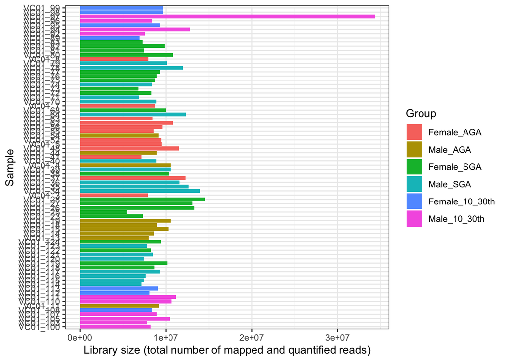

```r
dge$samples %>%
  ggplot(aes(x = AGRF_ID, y = lib.size, fill = sex_pathology)) +
  geom_bar(stat = "identity") +
  labs(y = "Library size (total number of mapped and quantified reads)",
       x = "Sample", fill = "Group") +
  coord_flip()
```

### Dimension Reduction

#### Multi Dimensional Scaling (MDS)

- Multi Dimensional Scaling (MDS) is a dimension reduction technique that summarises expression of the top 500 most variable genes expressed in each sample down to 2 dimensions, known as `Dimension 1` and `Dimension 2`. Dimension 1 represents the largest amount of variance that can be explained in the data. Plotting these principal components can help us visualise which samples show overall similar gene expression to each other -- similar samples will be situated closer to each other on the plot.
- Because our information is stored in a `DGEList` type of object, we can make use of the `glMDSPlot` function from the *Glimma* package to make an interactive MDS plot. The MDS plot produced using the function below can be viewed by navigating to the `glimma-plots` directory and clicking on the MDS-Plot.html file, or by clicking here.

```r
glMDSPlot(dge,
          labels = dge$samples$samplename,
          groups = dge$samples$sex_pathology)
```

#### Principal Component Analysis (PCA)

```r
# Perform PCA analysis:
pca_analysis <- prcomp(t(cpm(dge, log=TRUE)))
summary(pca_analysis)
```

```
## Importance of components:
##                            PC1      PC2      PC3      PC4      PC5      PC6
## Standard deviation     40.1263 25.13510 23.98075 20.41092 18.07489 16.74531
## Proportion of Variance  0.1368  0.05367  0.04885  0.03539  0.02775  0.02382
## Cumulative Proportion   0.1368  0.19045  0.23930  0.27469  0.30245  0.32627
##                             PC7      PC8      PC9    PC10     PC11     PC12
## Standard deviation     15.96635 15.17242 14.82222 13.9809 13.49082 12.98855
## Proportion of Variance  0.02166  0.01956  0.01866  0.0166  0.01546  0.01433
## Cumulative Proportion   0.34792  0.36748  0.38614  0.4027  0.41821  0.43254
##                            PC13     PC14     PC15     PC16     PC17    PC18
## Standard deviation     12.81461 12.45578 12.30543 12.26180 12.07552 11.8344
## Proportion of Variance  0.01395  0.01318  0.01286  0.01277  0.01239  0.0119
## Cumulative Proportion   0.44649  0.45967  0.47253  0.48531  0.49769  0.5096
##                            PC19     PC20     PC21     PC22     PC23     PC24
## Standard deviation     11.74995 11.67766 11.43782 11.35501 11.24279 11.15583
## Proportion of Variance  0.01173  0.01158  0.01111  0.01095  0.01074  0.01057
## Cumulative Proportion   0.52132  0.53291  0.54402  0.55497  0.56571  0.57628
##                            PC25     PC26     PC27    PC28     PC29     PC30
## Standard deviation     11.07777 10.97664 10.93045 10.8485 10.82741 10.66250
## Proportion of Variance  0.01042  0.01024  0.01015  0.0100  0.00996  0.00966
## Cumulative Proportion   0.58671  0.59694  0.60709  0.6171  0.62705  0.63671
##                           PC31     PC32     PC33     PC34    PC35     PC36
## Standard deviation     10.6329 10.59814 10.53100 10.50627 10.4605 10.42859
## Proportion of Variance  0.0096  0.00954  0.00942  0.00938  0.0093  0.00924
## Cumulative Proportion   0.6463  0.65585  0.66527  0.67465  0.6839  0.69319
##                            PC37     PC38     PC39     PC40     PC41     PC42
## Standard deviation     10.39596 10.32758 10.28535 10.22962 10.21941 10.17490
## Proportion of Variance  0.00918  0.00906  0.00899  0.00889  0.00887  0.00879
## Cumulative Proportion   0.70237  0.71143  0.72041  0.72930  0.73818  0.74697
##                            PC43     PC44     PC45    PC46    PC47    PC48
## Standard deviation     10.13020 10.04590 10.01153 9.98244 9.95632 9.92068
## Proportion of Variance  0.00872  0.00857  0.00851 0.00847 0.00842 0.00836
## Cumulative Proportion   0.75569  0.76426  0.77278 0.78124 0.78966 0.79802
##                           PC49    PC50   PC51    PC52    PC53    PC54    PC55
## Standard deviation     9.89405 9.84268 9.8240 9.81521 9.75844 9.70900 9.68689
## Proportion of Variance 0.00832 0.00823 0.0082 0.00818 0.00809 0.00801 0.00797
## Cumulative Proportion  0.80634 0.81457 0.8228 0.83095 0.83904 0.84705 0.85502
##                           PC56   PC57    PC58    PC59    PC60    PC61    PC62
## Standard deviation     9.67108 9.6446 9.59437 9.53500 9.51462 9.47511 9.46545
## Proportion of Variance 0.00795 0.0079 0.00782 0.00772 0.00769 0.00763 0.00761
## Cumulative Proportion  0.86297 0.8709 0.87869 0.88641 0.89410 0.90173 0.90934
##                           PC63    PC64    PC65    PC66    PC67    PC68    PC69
## Standard deviation     9.40830 9.35890 9.29162 9.24509 9.22179 9.19415 9.17972
## Proportion of Variance 0.00752 0.00744 0.00733 0.00726 0.00722 0.00718 0.00716
## Cumulative Proportion  0.91686 0.92430 0.93163 0.93889 0.94612 0.95330 0.96046
##                           PC70   PC71    PC72    PC73    PC74    PC75      PC76
## Standard deviation     9.14550 9.0783 9.05689 8.89118 8.68696 7.92892 7.859e-14
## Proportion of Variance 0.00711 0.0070 0.00697 0.00672 0.00641 0.00534 0.000e+00
## Cumulative Proportion  0.96756 0.9746 0.98153 0.98825 0.99466 1.00000 1.000e+00
```

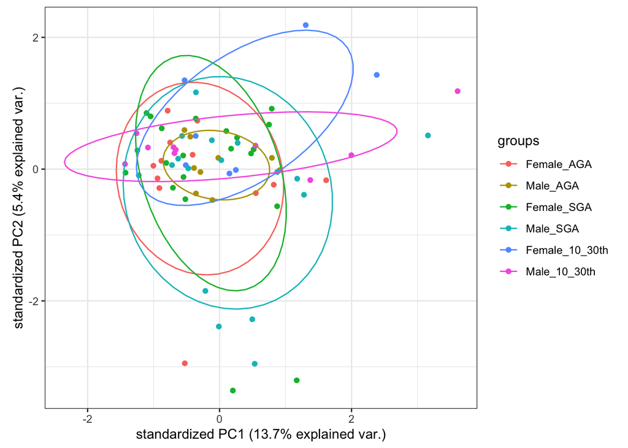

```r
# Create the plot:
pca_plot <- ggbiplot::ggbiplot(pca_analysis,
                   groups = dge$samples$sex_pathology,
                   ellipse = TRUE,
                   var.axes = FALSE)

pca_plot
```

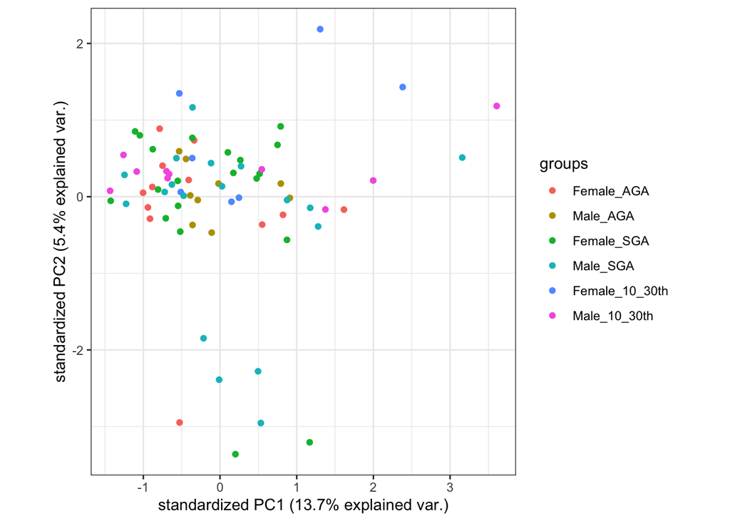

```r
ggbiplot::ggbiplot(pca_analysis,
                   groups = dge$samples$sex_pathology,
                   ellipse = FALSE,
                   var.axes = FALSE)
```

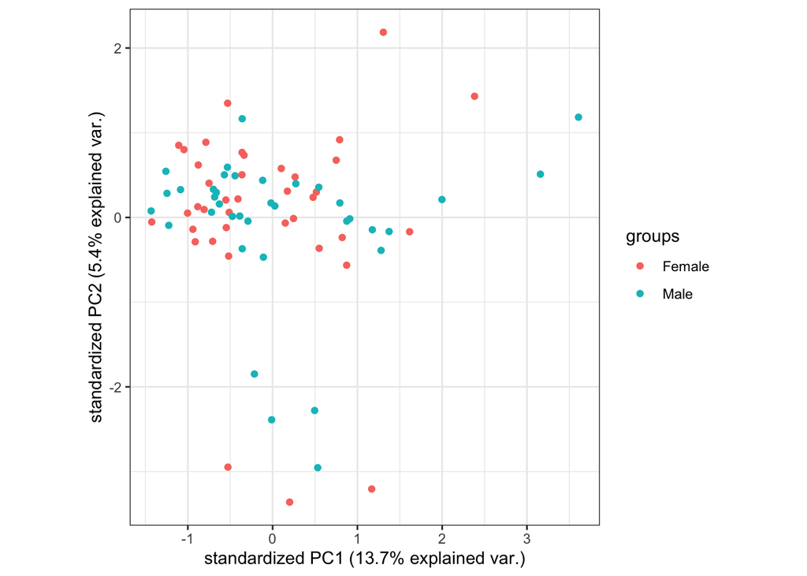

```r
ggbiplot::ggbiplot(pca_analysis,
                   groups = dge$samples$infantSex,
                   ellipse = FALSE,
                   var.axes = FALSE)
```

## Differential Expression

### Sex specific differential expression

- here I will use `edgeR` and `limma` for DE
- Full regression model will be run followed by contrasts for sex specific DE

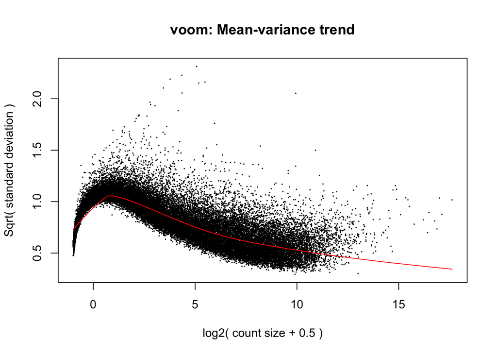

```r
# establish the design matrix
design_mRNA_sex_SGA <- model.matrix(~0 + sex_pathology + maternalAge,
                                    data = dge$samples)

# make the column names a little nicer
colnames(design_mRNA_sex_SGA) <- c("Female_AGA",
                                   "Male_AGA",
                                   "Female_SGA",
                                   "Male_SGA",
                                   "Female_10_30th",
                                   "Male_10_30th",
                                   "maternalAge")

# perform the voom quality weights
voom_mRNA_sex_SGA <- voom(dge, design_mRNA_sex_SGA, plot = TRUE)
```

```r
# fit the linear model
fit_mRNA_sex_SGA <- lmFit(voom_mRNA_sex_SGA, design_mRNA_sex_SGA)

# check the decide test
summary(decideTests(fit_mRNA_sex_SGA)) # before FDR correction
```

```
##        Female_AGA Male_AGA Female_SGA Male_SGA Female_10_30th Male_10_30th
## Down        17621    17503      17706    17861          17525        17427
## NotSig      10399    10332      10219    10042          10375        10634
## Up          15669    15854      15764    15786          15789        15628
##        maternalAge
## Down             0
## NotSig       43689
## Up               0
```

```r
# set the contrasts - this makes it easier to "see" what we're testing
contrast_mRNA_sex_SGA <- makeContrasts(female_SGA = Female_SGA-Female_AGA,
                                       male_SGA = Male_SGA-Male_AGA,
                                       levels = design_mRNA_sex_SGA)

# fit a linear regression to the contrast questions
fit_mRNA_sex_SGA <- contrasts.fit(fit_mRNA_sex_SGA, contrast_mRNA_sex_SGA)

# perform bayesian adjustment
fit_mRNA_sex_SGA <- eBayes(fit_mRNA_sex_SGA)

# summary table of the sex SGA fit
summary(decideTests(fit_mRNA_sex_SGA,
                    adjust.method = "fdr",
                    p.value = 0.05))
```

```
##        female_SGA male_SGA
## Down            0        0
## NotSig      43689    43689
## Up              0        0
```

```r
# all DE results for the female_SGA comparison
allTable_female_SGA <- topTable(fit_mRNA_sex_SGA,
                             coef = 1,
                             n = Inf,
                             sort = "p")

# saveRDS(allTable_female_SGA,
#         file = "differentialExpressionFiles/allTable_female_SGA.Rds")
#
# writexl::write_xlsx(as.data.frame(allTable_female_SGA),
#                     "differentialExpressionFiles/allTable_female_SGA")

# only significant (after fdr correction) DE results for the female_SGA comparison
topTable_female_SGA <- topTable(fit_mRNA_sex_SGA,
                             coef = 1,
                             n = Inf,
                             sort = "p",
                             p = 0.05,
                             adjust.method = "fdr") # requires eBayes.

# all DE results for the female_SGA comparison
allTable_male_SGA <- topTable(fit_mRNA_sex_SGA,
                             coef = 2,
                             n = Inf,
                             sort = "p")

# saveRDS(allTable_male_SGA,
#         file = "differentialExpressionFiles/allTable_male_SGA.Rds")
#
# writexl::write_xlsx(as.data.frame(allTable_male_SGA),
#                     "differentialExpressionFiles/allTable_male_SGA")

# only significant (after fdr correction) DE results for the female_SGA comparison
topTable_male_SGA <- topTable(fit_mRNA_sex_SGA,
                             coef = 2,
                             n = Inf,
                             sort = "p",
                             p = 0.05,
                             adjust.method = "fdr") # requires eBayes.
```

## Drop low expressed genes

```r
# drop genes that don't have an official gene symbol
dge_dropped <- dge[!is.na(dge$genes$gene_id), ]

# filter threshold
filterCPM <- 2
numSamples <- dim(dplyr::filter(dge_dropped$samples, outcome == "SGA" & infantSex == "Male"))[1]

# calculate the cpm value of a read count of 10 given the mean library size
# (to be used in the keep.genes)
cpm(10, mean(dge_dropped$samples$lib.size))
```

```
##          [,1]
## [1,] 1.029684
```

```r
# new df of unfiltered cpm for the reduced DGEList
rawCpm_mRNA <- cpm(dge_dropped)
# new df of unfiltered log 2 cpm for the reduced DGEList
rawlcpm_mRNA <- cpm(dge_dropped, log = TRUE, prior.count = 3)

# remove low expressed genes (filterCPM in numSamples PE)
keep.exprs <- rowSums(rawCpm_mRNA > filterCPM) >= numSamples

# Perform the filtering step and recalculate the TMM normalisation factors for each library.
dge_dropped <- dge_dropped[keep.exprs,,keep.lib.sizes = FALSE]

dim(dge_dropped)
```

```
## [1] 15470    76
```

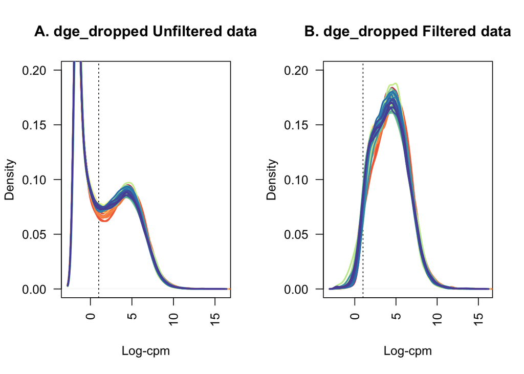

```r
## The density of log-CPM values for pre-filtered data
# (A) and post-filtered data
# (B) are shown for each sample.
## Dotted vertical lines mark the log-CPM of 1 threshold
# (equivalent to a CPM value of 2) used in the filtering step.
nsamples <- ncol(dge_dropped)
col_mRNA <- colorRampPalette(RColorBrewer::brewer.pal(11,"Spectral"))(ncol(dge_dropped))
par(mfrow=c(1,2))
plot(
  density(
    rawlcpm_mRNA[,1]
  ),
  col = col_mRNA[1],
  lwd = 2,
  ylim = c(0, 0.20),
  las = 2,
  main = "",
  xlab = "")
title(main = "A. dge_dropped Unfiltered data", xlab = "Log-cpm")
abline(v = 1, lty = 3)
for (i in 1:nsamples){
  den <- density(rawlcpm_mRNA[,i])
  lines(den$x, den$y, col = col_mRNA[i], lwd = 2)
}
#legend("topright", legend = samples$samplename, text.col = col, bty = "n")
#dev.off()
lcpm <- cpm(dge_dropped, log=TRUE)
plot(density(lcpm[,1]), col = col_mRNA[1], lwd = 2, ylim = c(0, 0.20), las = 2,
     main = "", xlab = "")
title(main = "B. dge_dropped Filtered data", xlab = "Log-cpm")
abline(v = 1, lty = 3)
for (i in 1:nsamples){
  den <- density(lcpm[,i])
  lines(den$x, den$y, col = col_mRNA[i], lwd = 2)
}
```

### Sex specific differential expression (dropped)

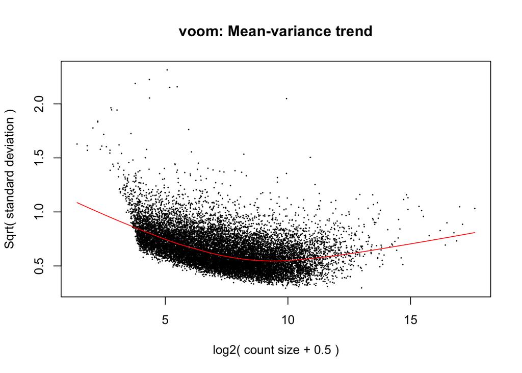

```r
# establish the design matrix
design_mRNA_sex_SGA_dropped <- model.matrix(~0 + sex_pathology,
                                    data = dge_dropped$samples)

# make the column names a little nicer
colnames(design_mRNA_sex_SGA_dropped) <- c("Female_AGA",
                                           "Male_AGA",
                                           "Female_SGA",
                                           "Male_SGA",
                                           "Female_10_30th",
                                           "Male_10_30th")

# perform the voom quality weights
voom_mRNA_sex_SGA_dropped <- voom(dge_dropped,
                                  design_mRNA_sex_SGA_dropped,
                                  plot = TRUE)
```

```r
# fit the linear model
fit_mRNA_sex_SGA_dropped <- lmFit(
  voom_mRNA_sex_SGA_dropped, design_mRNA_sex_SGA_dropped)

# check the decide test
summary(decideTests(fit_mRNA_sex_SGA_dropped)) # before FDR correction
```

```
##        Female_AGA Male_AGA Female_SGA Male_SGA Female_10_30th Male_10_30th
## Down            3        1          3        2              0           10
## NotSig        197      174        121      138            300          212
## Up          15270    15295      15346    15330          15170        15248
```

```r
# set the contrasts - this makes it easier to "see" what we're testing
contrast_mRNA_sex_SGA_dropped <- makeContrasts(
  female_SGA = Female_SGA-Female_AGA,
  male_SGA = Male_SGA-Male_AGA,
  levels = design_mRNA_sex_SGA_dropped)

# fit a linear regression to the contrast questions
fit_mRNA_sex_SGA_dropped <- contrasts.fit(fit_mRNA_sex_SGA_dropped,
                                          contrast_mRNA_sex_SGA_dropped)

# perform bayesian adjustment
fit_mRNA_sex_SGA_dropped <- eBayes(fit_mRNA_sex_SGA_dropped)

# summary table of the sex SGA fit
summary(decideTests(fit_mRNA_sex_SGA_dropped,
                    adjust.method = "fdr",
                    p.value = 0.05))
```

```
##        female_SGA male_SGA
## Down            0        0
## NotSig      15470    15470
## Up              0        0
```

```r
# all DE results for the female_SGA comparison
allTable_female_SGA_dropped <- topTable(fit_mRNA_sex_SGA_dropped,
                             coef = 1,
                             n = Inf,
                             sort = "p")

# saveRDS(allTable_female_SGA,
#         file = "differentialExpressionFiles/allTable_female_SGA_dropped.Rds")
#
# writexl::write_xlsx(as.data.frame(allTable_female_SGA),
#                     "differentialExpressionFiles/allTable_female_SGA_dropped")

# only significant (after fdr correction) DE results for the female_SGA comparison
topTable_female_SGA_dropped <- topTable(fit_mRNA_sex_SGA_dropped,
                             coef = 1,
                             n = Inf,
                             sort = "p",
                             p = 0.05,
                             adjust.method = "fdr") # requires eBayes.

# all DE results for the female_SGA comparison
allTable_male_SGA_dropped <- topTable(fit_mRNA_sex_SGA_dropped,
                             coef = 2,
                             n = Inf,
                             sort = "p")

# saveRDS(allTable_male_SGA,
#         file = "differentialExpressionFiles/allTable_male_SGA_dropped.Rds")
#
# writexl::write_xlsx(as.data.frame(allTable_male_SGA),
#                     "differentialExpressionFiles/allTable_male_SGA_dropped")

# only significant (after fdr correction) DE results for the female_SGA comparison
topTable_male_SGA_dropped <- topTable(fit_mRNA_sex_SGA_dropped,
                             coef = 2,
                             n = Inf,
                             sort = "p",
                             p = 0.05,
                             adjust.method = "fdr") # requires eBayes.
```